# Sick dataset analysis

Szymon Maksymiuk

16 04 2020

# 1 EDA

First let’s look at basic information about those data.

```r
summary(dataset_raw)
```

```
##       age           sex       on_thyroxine query_on_thyroxine
##  Min.   :  1.00   F   :2480   f:3308       f:3722
##  1st Qu.: 36.00   M   :1142   t: 464       t:  50
##  Median : 54.00   NA's: 150
##  Mean   : 51.74
##  3rd Qu.: 67.00
##  Max.   :455.00
##  NA's   :1
##  on_antithyroid_medication sick     pregnant thyroid_surgery I131_treatment
##  f:3729                    f:3625   f:3719   f:3719          f:3713
##  t:  43                    t: 147   t:  53   t:  53          t:  59
##
##
##
##
##
##  query_hypothyroid query_hyperthyroid lithium  goitre   tumor    hypopituitary
##  f:3538            f:3535             f:3754   f:3738   f:3676   f:3771
##  t: 234            t: 237             t:  18   t:  34   t:  96   t:   1
##
##
##
##
##
##  psych    TSH_measured      TSH          T3_measured       T3
##  f:3588   t:3403       Min.   :  0.005   t:3003      Min.   : 0.050
##  t: 184   f: 369       1st Qu.:  0.500   f: 769      1st Qu.: 1.600
##                        Median :  1.400               Median : 2.000
##                        Mean   :  5.087               Mean   : 2.014
##                        3rd Qu.:  2.700               3rd Qu.: 2.400
##                        Max.   :530.000               Max.   :10.600
##                        NA's   :369                   NA's   :769
##  TT4_measured      TT4        T4U_measured      T4U        FTI_measured
##  t:3541       Min.   :  2.0   t:3385       Min.   :0.250   t:3387
##  f: 231       1st Qu.: 88.0   f: 387       1st Qu.:0.880   f: 385
##               Median :103.0                Median :0.980
##               Mean   :108.3                Mean   :0.995
##               3rd Qu.:124.0                3rd Qu.:1.080
##               Max.   :430.0                Max.   :2.320
##               NA's   :231                  NA's   :387
##       FTI        TBG_measured      TBG       referral_source      Class
##  Min.   :  2.0   f:3772       Min.   : NA    SVHC : 386      negative:3541
##  1st Qu.: 93.0                1st Qu.: NA    other:2201      sick    : 231
##  Median :107.0                Median : NA    SVI  :1034
##  Mean   :110.5                Mean   :NaN    STMW : 112
##  3rd Qu.:124.0                3rd Qu.: NA    SVHD :  39
##  Max.   :395.0                Max.   : NA
##  NA's   :385                  NA's   :3772
```

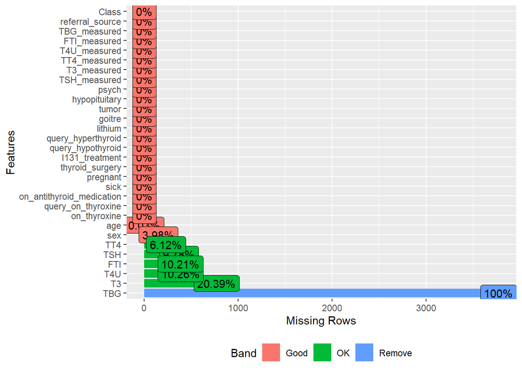

```r
DataExplorer::plot_missing(dataset_raw)
```

It is easy to spot straight away that one column, which is `TBG` contains 0 information. Therefore we will have it removed. Accordingly `TBG_measured` and `hypopituitary` have no information as well.

```r
dataset_raw <- dataset_raw[,-which(names(dataset_raw)=="TBG")]
dataset_raw <- dataset_raw[,-which(names(dataset_raw)=="TBG_measured")]
dataset_raw <- dataset_raw[,-which(names(dataset_raw)=="hypopituitary")]
```

Before we move forward I would like to transform columns. I want factors with 2 levels to become a numeric vector with values 0 and 1.

```r
for (i in 1:ncol(dataset_raw)) {
  if (!is.null(levels(dataset_raw[,i]))) {
    if (all(levels(dataset_raw[,i]) %in% c("f", "t"))) {
      dataset_raw[,i] <- as.numeric(ifelse(dataset_raw[,i] == 't', 1, 0))
    } else if (all(levels(dataset_raw[,i]) %in% c("sick", "negative"))) {
      dataset_raw[,i] <- as.numeric(ifelse(dataset_raw[,i] == 'sick', 1, 0))
    } else if (all(levels(dataset_raw[,i]) %in% c("F", "M"))) {
      dataset_raw[,i] <- as.numeric(ifelse(dataset_raw[,i] == 'M', 1, 0))
    }
  }
}
dataset_raw$Class <- as.factor(dataset_raw$Class)
```

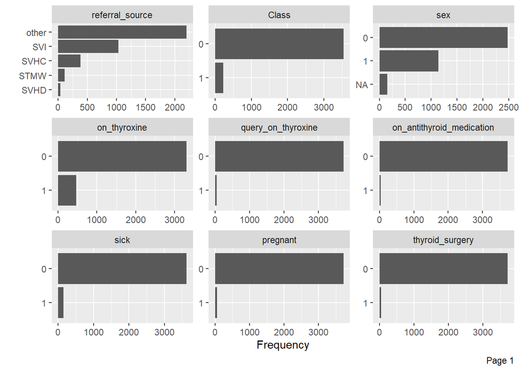

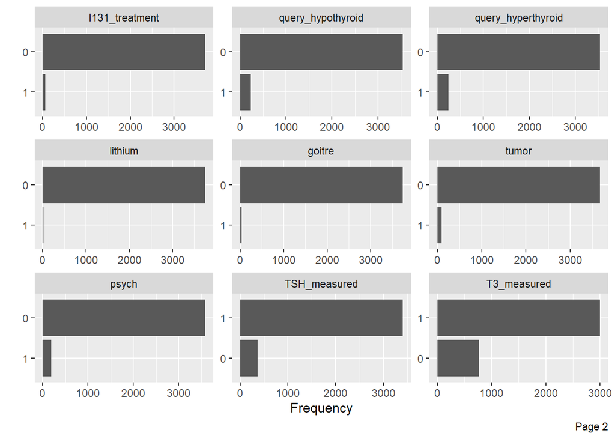

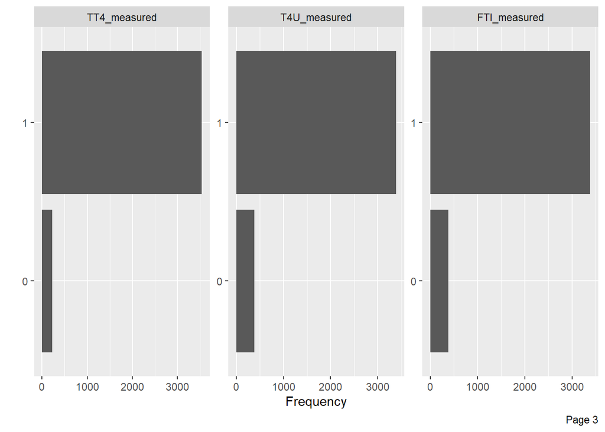

```r
DataExplorer::plot_bar(dataset_raw)
```

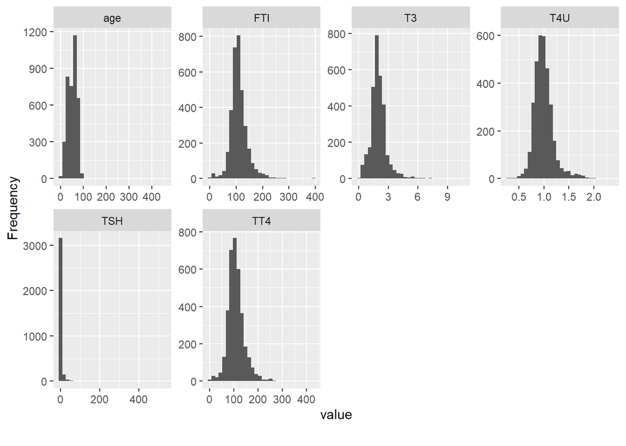

```r
DataExplorer::plot_histogram(dataset_raw)
```

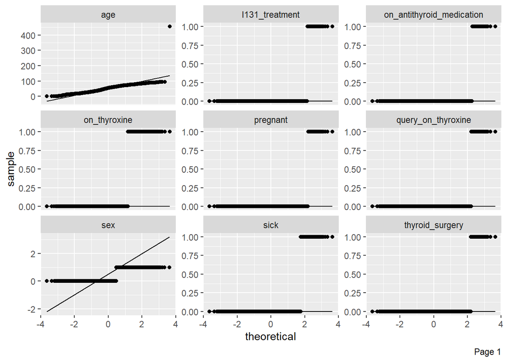

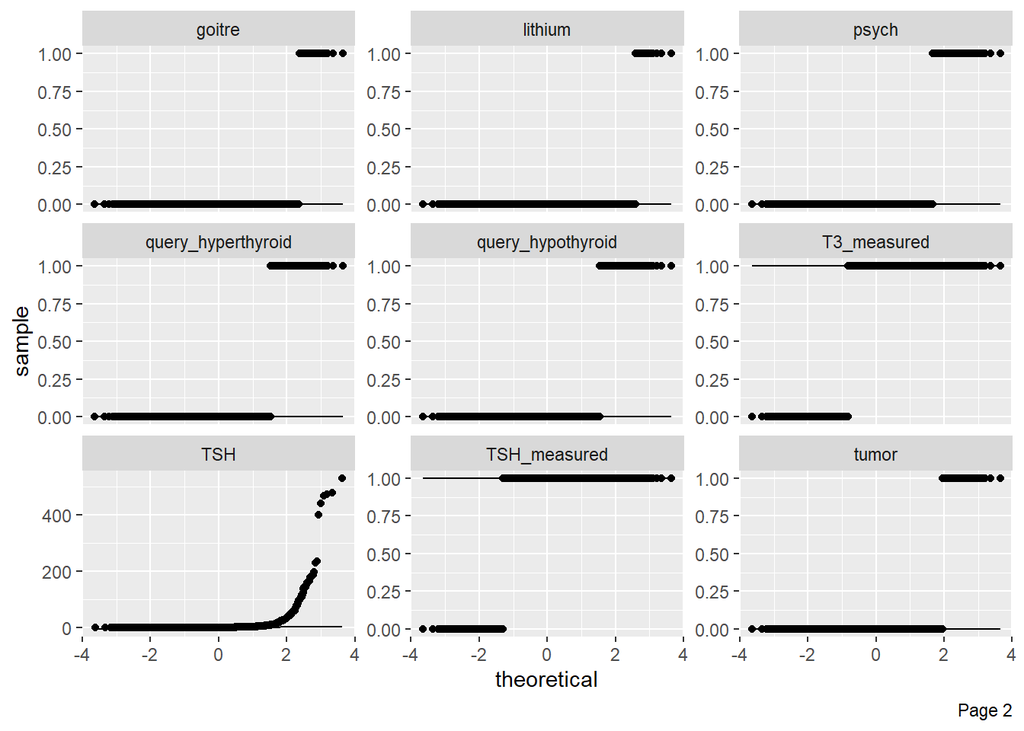

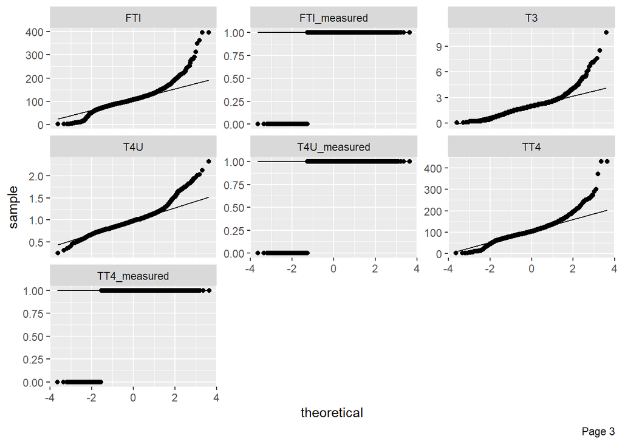

```r
DataExplorer::plot_qq(dataset_raw)
```

```r
dataset_raw[dataset_raw$age>200,]
```

|  | age | sex | on_thyroxine | query_on_thyroxine | on_antithyroid_medication | sick | pregnant | thyroid_surgery | I131_treatment | query_hypothyroid | query_hyperthyroid | lithium | goitre | tumor | psych | TSH_measured | TSH | T3_measured | T3 | TT4_measured | TT4 | T4U_measured | T4U | FTI_measured | FTI | referral_source | Class |
| --- | --- | --- | --- | --- | --- | --- | --- | --- | --- | --- | --- | --- | --- | --- | --- | --- | --- | --- | --- | --- | --- | --- | --- | --- | --- | --- | --- |
| 1364 | 455 | 0 | 0 | 0 | 0 | 0 | 0 | 0 | 0 | 0 | 0 | 0 | 0 | 0 | 0 | 1 | 1.1 | 1 | 2 | 1 | 118 | 1 | 1.13 | 1 | 104 | SVI | 0 |
| NA | NA | NA | NA | NA | NA | NA | NA | NA | NA | NA | NA | NA | NA | NA | NA | NA | NA | NA | NA | NA | NA | NA | NA | NA | NA | NA | NA |

It is obviously a big mistake in data and therefore that row will be removed at the preprocessing stage.

# 2 Preprocessing

Let’s remove mistaken observation mentioned in the previous paragraph

Before we start proper preprocessing we have to split our data to test and train sets.

```r
dataset_test <- dataset_raw[-test_index,]
dataset_train <- dataset_raw[test_index,]
```

Now we need to handle missing values in observations. `mice` package will be used along with `pmm` method to impute missing values.

```r
library(mice)
m <- mice(dataset_train, method = "pmm", printFlag = FALSE)
dataset <- complete(m, 3)
```

# 3 Modeling

Once we have our preprocessed data, it is hight time to start modeling part. `mlr` framework for modeling will be used. I planned on using two types of white-box models:

- decision tree
- logistic regression.

First I’m going to create a standard model that we want to improve.

```r
library("mlr")
library("auprc")
library("PRROC")

my_auprc_fun = function(task, model, pred, feats, extra.args) {
  prob <- pred$data$prob.1
  y_truth <- getPredictionTruth(pred)


  fg <- prob[y_truth == 1]
  bg <- prob[y_truth == 0]

  pr <- pr.curve(scores.class0 = fg, scores.class1 = bg, curve = T)
  auprc <- pr$auc.integral
  auprc
}

my_auprc = makeMeasure(
  id = "myauprc", name = "AUPRC",
  properties = c("classif", "classif.multi", "req.pred", "req.truth"),
  minimize = FALSE, best = 1, worst = 0,
  fun = my_auprc_fun
)

task <- makeClassifTask(data = dataset, target = "Class")
lrn_tree <- makeLearner("classif.rpart", predict.type = "prob")

model_tree <- train(lrn_tree, task)

p_tree <- predict(model_tree, newdata = dataset_test)

performance(p_tree, list(auc, my_auprc))
```

```
##       auc   myauprc
## 0.9226949 0.8594002
```

```r
library(mlrMBO)
par.set <- makeParamSet(
  makeIntegerParam("minsplit", 3, 40),
  makeIntegerParam("minbucket", 2, 40),
  makeNumericParam("cp", -10, -3, trafo = function(x) 2^x),
  makeIntegerParam("maxdepth", 1, 30)
)
cv <- makeResampleDesc("CV", iters = 5L)
ctrl <- makeMBOControl()
ctrl <- setMBOControlTermination(ctrl, iters = 100)
tune_ctrl <- makeTuneControlMBO(mbo.control = ctrl)
res_tree <- tuneParams(lrn_tree, task, cv, par.set = par.set, control = tune_ctrl)
```

Tuning has slightly imporved our model. Here are results.

```r
lrn_tree <- makeLearner("classif.rpart", predict.type = "prob", par.vals = list(minsplit = 25,
                                                                                minbucket = 7,
                                                                                cp = 0.00108))

model_tree <- train(lrn_tree, task)

p_tree <- predict(model_tree, newdata = dataset_test)

performance(p_tree, list(auc, my_auprc))
```

```
##       auc   myauprc
## 0.9603813 0.9121878
```